# Homework of SA23204189

Zheyu Li

2023-12-04

# HW0 2023-09-11

# Question1

## 对不同种类的哺乳动物的脑重和体重进行回归分析

# Answer

## 准备工作

```r
library(alr4)
```

```r
library(ggplot2)
```

```r
str(brains)#查看数据集brains的数据类型、变量名称和观测值
```

```
## 'data.frame':    62 obs. of  2 variables:
##  $ BrainWt: num  44.5 15.5 8.1 423 119.5 ...
##  $ BodyWt : num  3.38 0.48 1.35 464.98 36.33 ...
```

```r
summary(brains)#显示脑重、体重的均值、分位数
```

```
##     BrainWt            BodyWt
##  Min.   :   0.14   Min.   :   0.005
##  1st Qu.:   4.25   1st Qu.:   0.600
##  Median :  17.25   Median :   3.342
##  Mean   : 283.13   Mean   : 198.794
##  3rd Qu.: 166.00   3rd Qu.:  48.201
##  Max.   :5711.86   Max.   :6654.180
```

## 回归模型的调用

```r
model<-lm(log10(BrainWt)~log10(BodyWt),data=brains)
summary(model)
```

```
##
## Call:
## lm(formula = log10(BrainWt) ~ log10(BodyWt), data = brains)
##
## Residuals:
##      Min       1Q   Median       3Q      Max
## -0.74503 -0.21380 -0.02676  0.18934  0.84615
##
## Coefficients:
##               Estimate Std. Error t value Pr(>|t|)
## (Intercept)    0.92713    0.04171   22.23   <2e-16 ***
## log10(BodyWt)  0.75169    0.02846   26.41   <2e-16 ***
## ---
## Signif. codes:  0 '***' 0.001 '**' 0.01 '*' 0.05 '.' 0.1 ' ' 1
##
## Residual standard error: 0.3015 on 60 degrees of freedom
## Multiple R-squared:  0.9208, Adjusted R-squared:  0.9195
## F-statistic: 697.4 on 1 and 60 DF,  p-value: < 2.2e-16
```

## 数据散点图和拟合曲线的绘制

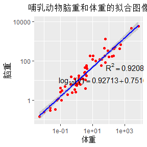

```r
ggplot(data=brains,aes(y=BrainWt,x=BodyWt))+
  scale_x_log10()+scale_y_log10()+                                   #将坐标尺度修改为每格10倍
  geom_point(color="red")+                                           #画点
  stat_smooth(method=lm,formula=y~x,color="blue")+                   #画回归直线
  ylab("脑重")+xlab("体重")+                                         #修改坐标名称
  ggtitle("哺乳动物脑重和体重的拟合图像")+                           #加标题
  theme(plot.title = element_text(hjust=0.5))+
  annotate("text",label=expression(R^2==0.9208),x=1000,y=50)+        #加图例
  annotate("text",label=expression(log[10](y)==0.92713+0.75169%.%log[10](x)),x=500,y=10)
```

## 用回归模型做预测

```r
BodyWt_min<-min(brains$BodyWt)
BodyWt_max<-max(brains$BodyWt)
predicted<-data.frame(BodyWt=seq(BodyWt_min,BodyWt_max,length.out=100)) #创建需要预测的自变量数值
predicted$BrainWt <- 10^(predict(model,predicted)) #预测数值
head(predicted)
```

```
##      BodyWt     BrainWt
## 1   0.00500   0.1575703
## 2  67.21889 199.9064035
## 3 134.43278 336.5849110
## 4 201.64667 456.5159502
## 5 268.86056 566.7201444
## 6 336.07444 670.2137763
```

## 模型检验

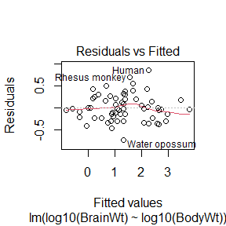

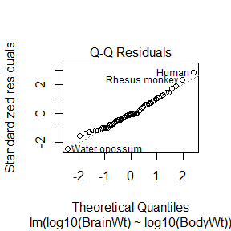

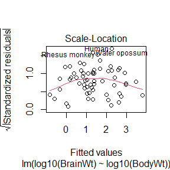

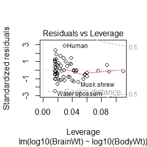

```r
plot(model)
```

# Question2

## 生成标准柯西分布的随机样本

# Answer

柯西分布的概率密度函数为
$$f(x)=\frac{1}{\pi}\frac{1}{1+x^2},
x\in\mathbb{R}$$

柯西分布的累积分布函数为
$$F(x)=\frac{1}{\pi}\bigg(\arctan
x+\frac{\pi}{2}\bigg), x\in\mathbb{R}$$

柯西分布累积分布函数的逆函数为
$$F^{-1}(x)=\tan(\pi x-\frac{\pi}{2}),
x\in[0,1]$$

## 标准柯西变量的生成

```r
u<-runif(1000)      #生成1000个标准柯西变量
x<-tan(pi*u-pi/2)
head(x)             #显示头几个柯西变量的值
```

```
## [1]  0.6636075 -0.2240909 -0.2965398  2.0624042 -2.0198228  1.5197965
```

## 画出柯西变量的样本直方图

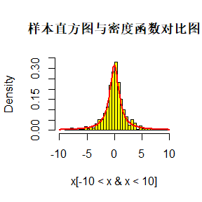

```r
hist(x[-10<x&x<10],prob=T,xlim=c(-10,10),ylim=c(0,0.35),breaks=30,main="样本直方图与密度函数对比图",col="yellow")
curve(1/pi*1/(1+x^2),col="red",add=T,lwd=2)
```

# HW1 2023-09-18

# Question1

利用逆变换法复现函数sample的部分功能(replace=True)

# Answer

## 编写函数

```r
my.sample<-function(x,size,prob=rep(1/length(x),length(x))){
  #x代表样本空间，size代表样本大小，prob代表概率(缺省值情况下为等概率)

  stopifnot(length(x)==length(prob))
  #x的长度应当和prob的长度相等

  cp<-cumsum(prob)
  U<-runif(size)              #生成均匀分布样本
  R<-x[findInterval(U,cp)+1]  #生成所求样本
  return(R)
}
```

## 用sample函数生成随机变量

```r
set.seed(1)
x<-c(1,2,"a",TRUE)
sample(x,30,replace=TRUE,prob=c(0.1,0.2,0.3,0.4))
```

```
##  [1] "TRUE" "TRUE" "a"    "1"    "TRUE" "2"    "1"    "a"    "a"    "TRUE"
## [11] "TRUE" "TRUE" "a"    "TRUE" "2"    "a"    "2"    "1"    "TRUE" "2"
## [21] "1"    "TRUE" "a"    "TRUE" "TRUE" "TRUE" "TRUE" "TRUE" "2"    "TRUE"
```

## 用my.sample函数生成随机变量

```r
set.seed(2)
my.sample(x,30,prob=c(0.1,0.2,0.3,0.4))
```

```
##  [1] "2"    "TRUE" "a"    "2"    "TRUE" "TRUE" "2"    "TRUE" "a"    "a"
## [11] "a"    "2"    "TRUE" "2"    "a"    "TRUE" "TRUE" "2"    "a"    "1"
## [21] "TRUE" "a"    "TRUE" "2"    "a"    "a"    "2"    "a"    "TRUE" "2"
```

# Question2

3.2 标准拉普拉斯分布具有密度

$$f(x)=\frac{1}{2}e^{-|x|},
x\in\mathbb{R}.$$

使用逆变换法生成一个大小为1000，服从拉普怕死分布的随机样本.使用本章中给出的一种方法来比较生成样本和目标分布.

# Answer

拉普拉斯分布的累积分布函数为

$$F(x)=\begin{cases}
\frac{1}{2}e^x,\ x<0 \\
1-\frac{1}{2}e^{-x},\ x\geqslant0
\end{cases}$$

# HW2 2023-09-25

# Question 1

Proof that what value ρ =l/d should take to minimize the asymptotic variance of $\hat π$? (m ∼ B(n, p), using δ method)

# Question 2

Take three different values of ρ (0 ≤ ρ ≤ 1, including $\rho_{min}$) and use Monte Carlo simulation to verify your answer. (n = $10^6$ , Number of repeated simulations K = 100)

## 编写函数

```r
pi_est<-function(rho,n,K){   #rho=l/d,n为针数，K为重复模拟的次数
  l<-rho
  d<-1
  pi_hat<-numeric(K)

  for(i in 1:K){
  X<-runif(n,0,d/2)  #针心到平行线的最近距离
  Y<-runif(n,0,pi/2) #针与平行线的夹角
  pi_hat[i]<-2*l/d/mean(0.5*l*sin(Y)>X)
  }

  pi_hat
}
```

## 带值计算

```r
n<-10^6
K<-100

set.seed(1)
pi_hat1<-pi_est(0.5,n,K)
pi_hat2<-pi_est(0.8,n,K)
pi_hat3<-pi_est(1,n,K)
print(paste("rho=0.5时的pi估计值为",mean(pi_hat1),"方差为",var(pi_hat1)),sep="")
```

```
## [1] "rho=0.5时的pi估计值为 3.1405166332758 方差为 2.91869475026967e-05"
```

```r
print(paste("rho=0.8时的pi估计值为",mean(pi_hat2),"方差为",var(pi_hat2)),sep="")
```

```
## [1] "rho=0.8时的pi估计值为 3.14203287598114 方差为 7.60691022700376e-06"
```

```r
print(paste("rho=1时的pi估计值为",mean(pi_hat3),"方差为",var(pi_hat3)),sep="")
```

```
## [1] "rho=1时的pi估计值为 3.14120711467485 方差为 6.91280306535536e-06"
```

从结果中可以看到，随着rho的增大，pi估计值的误差和方差都越来越小

# Question 3

书上练习5.6

# Question 4

书上练习5.7

## 通过模拟计算两方法估计值的均值和方差

```r
n<-10000  #每次取10000个数估计积分值
M<-100    #将积分值估计100次
Y1<-numeric(M)
Y2<-numeric(M)

set.seed(8)
for(i in 1:M){
X<-runif(n)

#简单蒙特卡罗方法
y1<-exp(X)
Y1[i]<-mean(y1)

#对偶变量法
y2<-c(exp(X[1:n/2]),exp(1-X[1:n/2]))
Y2[i]<-mean(y2)
}
```

## 结果显示

```r
mean(Y1) #简单蒙特卡罗方法估计量均值
```

```
## [1] 1.718043
```

```r
var(Y1)  #简单蒙特卡罗方法估计量方差
```

```
## [1] 2.271879e-05
```

```r
mean(Y2) #对偶变量法估计量均值
```

```
## [1] 1.718438
```

```r
var(Y2)  #对偶变量法估计量方差
```

```
## [1] 8.108331e-07
```

```r
print(paste("该实验中，对偶变量法将方差缩减了",round(100*(1-var(Y2)/var(Y1)),2),"%",sep=""))
```

```
## [1] "该实验中，对偶变量法将方差缩减了96.43%"
```

# HW3 2023-10-09

# Question 1

作业证明题

# Question 2

习题5.13

Find two importance functions f1 and f2 that are supported on (1, ∞) and are ‘close’ to
$$g(x)=\frac{x^2}{\sqrt{2\pi}}e^{-x^2/2},\ x>1$$
Which of your two importance functions should produce the smaller variance in estimating
$$\int_1^{+\infty}
\frac{x^2}{\sqrt{2\pi}}e^{-x^2/2} dx$$

# Answer

```r
m <- 1e6
est <- sd <- numeric(2)
g <- function(x) {
  x^2 * exp(-x^2/2) / sqrt(2*pi) * (x > 1)
}

set.seed(1)

#构造f1
f1<-function(x){
  exp(-x^2/2) / (1-pnorm(1)) /sqrt(2*pi)
}

#生成m个服从f1的随机变量
x<-numeric(m)
item<-1
while(item<=m){
  x[item]<-rnorm(1)
  if(x[item]>1)
    item<-item+1
}

fg<-g(x)/f1(x)
est[1]<-mean(fg)
sd[1]<-sd(fg)

#构造f2
f2<-function(x){
  1/(x^2)
}

#生成m个服从f2的随机变量(这里运用了逆函数法)
u<-runif(m)
x<-1/(1-u)

fg<-g(x)/f2(x)
est[2]<-mean(fg)
sd[2]<-sd(fg)

#估计值的均值
est
```

```
## [1] 0.4007810 0.4004671
```

```r
#估计值的标准差
sd
```

```
## [1] 0.2620246 0.3056350
```

# Question 3

习题5.14

Obtain a Monte Carlo estimate of
$$\int_1^{+\infty} \frac{x^2}{\sqrt{2\pi}}e^{-x^2/2} dx$$
by importance sampling.

# Answer

由5.13知该积分的蒙特卡罗估计为0.4008

下面画出重要函数和原函数的比较图：

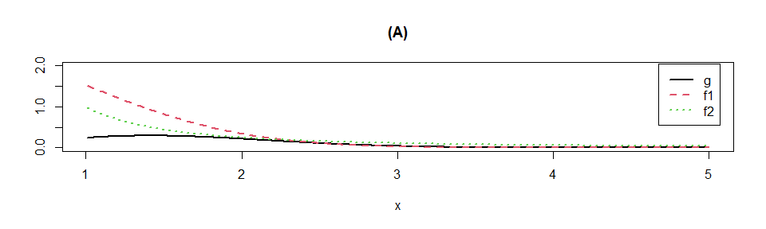

```r
    x <- seq(1.01, 5, .01)
    w<-2
    gs<-c("g","f1","f2")

    #for color change lty to col
    #figure (a)
    plot(x, g(x), type = "l", ylab = "",
         ylim = c(0,2), lwd = w, col=1,main='(A)')
    lines(x, f1(x), lty = 2, lwd = w,col=2)
    lines(x, f2(x), lty = 3, lwd = w,col=3)
    legend("topright", legend = gs,
           lty = 1:3, lwd = w, inset = 0.02,col=1:3)
```

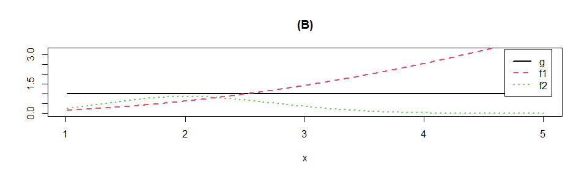

```r
    #figure (b)
    plot(x, rep(1,length(x)), type = "l", ylab = "",
        ylim = c(0,3.2), lty = 1, lwd = w,col=1,main='(B)')
    lines(x, g(x)/f1(x), lty = 2, lwd = w,col=2)
    lines(x, g(x)/f2(x), lty = 3, lwd = w,col=3)
    legend("topright", legend = gs,
           lty = 1:3, lwd = w, inset = 0.02,col=1:3)
```

# Question 4

习题5.15

Obtain the stratified importance sampling estimate in Example 5.13 and compare it with the result of Example 5.10.

# Answer

```r
M <- 10000; k <- 5 # 分成5个子区间
r <- M/k #每个区间取的随机数个数
N <- 50 #实验次数
T2 <- numeric(k)
est <- matrix(0, N, 2)
g<-function(x)exp(-x)/(1+x^2)*(x>0)*(x<1)

set.seed(2)

for (i in 1:N) {
  #使用例5.10中的方法
  u<-runif(M)
  x<- -log(1-u*(1-exp(-1)))
  fg<-g(x)/exp(-x)*(1-exp(-1))
  est[i,1]<-mean(fg)

  #使用分层抽样法
  for(j in 1:k){
    u<-runif(r,(j-1)/k,j/k)
    x<- -log(1-u*(1-exp(-1)))
    fg[((j-1)*r+1):(j*r)]<-g(x)/exp(-x)*(1-exp(-1))
  }
  est[i,2]<-mean(fg)
}

#两种方法的均值对比
round(apply(est,2,mean),5)
```

```
## [1] 0.52471 0.52475
```

```r
#两种方法的标准差对比
round(apply(est,2,sd),5)
```

```
## [1] 0.00105 0.00023
```

和例5.10中的结果相比，例5.13的分层抽样法得到的估计量拥有更小的标准差，所以更好

# Question 5

习题6.5

Suppose a 95% symmetric t-interval is applied to estimate a mean, but the sample data are non-normal. Then the probability that the confidence interval covers the mean is not necessarily equal to 0.95. Use a Monte Carlo experiment to estimate the coverage probability of the t-interval for random samples of χ2(2) data with sample size n = 20. Compare your t-interval results with the simulation results in Example 6.4. (The t-interval should be more robust to departures from normality than the interval for variance.)

# Answer

```r
m<-100000 #重复实验次数
n<-20   #每次实验取20个样本
df<-2   #自由度为2的卡方分布
alpha<-0.05
d1<-numeric(m) #置信下限
d2<-numeric(m) #置信上限

set.seed(3)

for(i in 1:m){
  x<-rchisq(n,df)
  d1[i]<-mean(x)-sd(x)*qt(1-alpha/2,n-1)/sqrt(n)
  d2[i]<-mean(x)+sd(x)*qt(1-alpha/2,n-1)/sqrt(n)
}

mu0<-2
mean(d1<mu0&d2>mu0) #mu0落在置信区间的概率
```

```
## [1] 0.91926
```

从结果上来看，均值真实值落在t区间的概率小于0.95，和例6.4相比，造成这个结果的原因是df=2的卡方分布并不是无偏分布

# Question 6

习题6.A

Use Monte Carlo simulation to investigate whether the empirical Type I error rate of the t-test is approximately equal to the nominal significance level α, when the sampled population is non-normal. The t-test is robust to mild departures from normality. Discuss the simulation results for the cases where the sampled population is (i) χ2(1), (ii) Uniform(0,2), and (iii) Exponential(rate=1). In each case, test H0 : µ = µ0 vs H0 : µ = µ0, where µ0 is the mean of χ2(1), Uniform(0,2), and Exponential(1), respectively.

# Answer

### 1.df=1的卡方分布

```r
m<-100000 #重复实验次数
n<-20   #每次实验取20个样本
df<-1   #自由度为1的卡方分布
alpha<-0.05
d1<-numeric(m) #置信下限
d2<-numeric(m) #置信上限

set.seed(4)

for(i in 1:m){
  x<-rchisq(n,df)
  d1[i]<-mean(x)-sd(x)*qt(1-alpha/2,n-1)/sqrt(n)
  d2[i]<-mean(x)+sd(x)*qt(1-alpha/2,n-1)/sqrt(n)
}

mu0<-1
1-mean(d1<mu0&d2>mu0) #mu0落在置信区间外的概率
```

```
## [1] 0.10744
```

### 2.(0,2)的均匀分布

```r
m<-100000 #重复实验次数
n<-20   #每次实验取20个样本
alpha<-0.05
d1<-numeric(m) #置信下限
d2<-numeric(m) #置信上限

set.seed(5)

for(i in 1:m){
  x<-runif(n,0,2)
  d1[i]<-mean(x)-sd(x)*qt(1-alpha/2,n-1)/sqrt(n)
  d2[i]<-mean(x)+sd(x)*qt(1-alpha/2,n-1)/sqrt(n)
}

mu0<-1
1-mean(d1<mu0&d2>mu0) #mu0落在置信区间外的概率
```

```
## [1] 0.05206
```

### 3.参数为1的指数分布

```r
m<-100000 #重复实验次数
n<-20   #每次实验取20个样本
alpha<-0.05
d1<-numeric(m) #置信下限
d2<-numeric(m) #置信上限

set.seed(6)

for(i in 1:m){
  x<-rexp(n,1)
  d1[i]<-mean(x)-sd(x)*qt(1-alpha/2,n-1)/sqrt(n)
  d2[i]<-mean(x)+sd(x)*qt(1-alpha/2,n-1)/sqrt(n)
}

mu0<-1
1-mean(d1<mu0&d2>mu0) #mu0落在置信区间外的概率
```

```
## [1] 0.08175
```

# HW4 2023-10-16

# Question 1

# Answer

### 生成p值并进行排序

```r
options(max.print=3000)

m<-1000
m1<-950
m2<-50

set.seed(1)
p<-numeric(m)                 #生成1000个p值
p[1:m1]<-runif(m1,0,1)        #前950个变量服从(0,1)均匀分布
p[(m1+1):m]<-rbeta(m2,0.1,1)  #后50个变量服从beta(0.1,1)

p.sorted<-sort(p)
p.ordered<-order(p)

length(p)
```

```
## [1] 1000
```

```r
head(p)
```

```
## [1] 0.2655087 0.3721239 0.5728534 0.9082078 0.2016819 0.8983897
```

```r
head(p.sorted)
```

```
## [1] 2.551198e-18 4.483793e-18 7.931396e-15 3.099828e-12 5.793331e-12
## [6] 1.550742e-10
```

```r
head(p.ordered)
```

```
## [1]  985  994  987  992 1000  952
```

### 使用Benjamini-Hochberg法和bonferroni法进行p值校正

```r
p.adj1 <- p.sorted/(1:m)*m
p.adj2 <- p.adjust(p.sorted,method='BH')
p.adj3 <- p.adjust(p.sorted,method='bonferroni')
rbind(p.adj1,p.adj2,p.adj3)[,1:50]
```

```
##                [,1]         [,2]         [,3]         [,4]         [,5]
## p.adj1 2.551198e-15 2.241896e-15 2.643799e-12 7.749569e-10 1.158666e-09
## p.adj2 2.241896e-15 2.241896e-15 2.643799e-12 7.749569e-10 1.158666e-09
## p.adj3 2.551198e-15 4.483793e-15 7.931396e-12 3.099828e-09 5.793331e-09
##                [,6]         [,7]         [,8]         [,9]        [,10]
## p.adj1 2.584571e-08 2.383914e-08 2.516892e-08 2.754730e-08 2.983684e-08
## p.adj2 2.383914e-08 2.383914e-08 2.516892e-08 2.754730e-08 2.983684e-08
## p.adj3 1.550742e-07 1.668740e-07 2.013514e-07 2.479257e-07 2.983684e-07
##               [,11]        [,12]        [,13]        [,14]        [,15]
## p.adj1 8.782144e-08 6.020272e-07 6.418532e-06 6.047393e-06 8.736331e-05
## p.adj2 8.782144e-08 6.020272e-07 6.047393e-06 6.047393e-06 8.736331e-05
## p.adj3 9.660359e-07 7.224326e-06 8.344091e-05 8.466350e-05 1.310450e-03
##               [,16]        [,17]      [,18]       [,19]       [,20]      [,21]
## p.adj1 9.414001e-05 0.0003365488 0.00182761 0.001997266 0.002607785 0.01170534
## p.adj2 9.414001e-05 0.0003365488 0.00182761 0.001997266 0.002607785 0.01170534
## p.adj3 1.506240e-03 0.0057213300 0.03289697 0.037948053 0.052155696 0.24581205
##             [,22]      [,23]      [,24]      [,25]      [,26]      [,27]
## p.adj1 0.01520859 0.01642448 0.03011291 0.03093998 0.03651291 0.04869098
## p.adj2 0.01520859 0.01642448 0.03011291 0.03093998 0.03651291 0.04869098
## p.adj3 0.33458906 0.37776297 0.72270993 0.77349961 0.94933571 1.00000000
##             [,28]      [,29]      [,30]      [,31]      [,32]     [,33]
## p.adj1 0.06560208 0.06664947 0.07935846 0.07930634 0.08988302 0.1085257
## p.adj2 0.06560208 0.06664947 0.07930634 0.07930634 0.08988302 0.1085257
## p.adj3 1.00000000 1.00000000 1.00000000 1.00000000 1.00000000 1.0000000
##            [,34]     [,35]     [,36]    [,37]     [,38]     [,39]     [,40]
## p.adj1 0.1401896 0.1947133 0.1995287 0.219688 0.2518893 0.2575544 0.2759018
## p.adj2 0.1401896 0.1947133 0.1995287 0.219688 0.2518893 0.2575544 0.2700046
## p.adj3 1.0000000 1.0000000 1.0000000 1.000000 1.0000000 1.0000000 1.0000000
##            [,41]     [,42]     [,43]     [,44]     [,45]     [,46]     [,47]
## p.adj1 0.2719392 0.2700046 0.2734822 0.2972176 0.2913270 0.2910942 0.3534513
## p.adj2 0.2700046 0.2700046 0.2734822 0.2910942 0.2910942 0.2910942 0.3475480
## p.adj3 1.0000000 1.0000000 1.0000000 1.0000000 1.0000000 1.0000000 1.0000000
##           [,48]     [,49]     [,50]
## p.adj1 0.347548 0.3664846 0.4202369
## p.adj2 0.347548 0.3664846 0.4202369
## p.adj3 1.000000 1.0000000 1.0000000
```

### 生成在alpha=0.1下原假设的接受情况

```r
alpha<-0.1
p.refuse2<-(p.adj2>0.1) #TRUE为接受原假设，FALSE为拒绝原假设
p.refuse3<-(p.adj3>0.1)
```

### 生成两种校正法的FWER,FDR和TPR

```r
A<-matrix(nrow=2,ncol=3)
colnames(A)<-c("FWER","FDR","TPR")
rownames(A)<-c("Bonf","B-H")
A[1]<-1-mean(p.refuse3)
A[2]<-1-mean(p.refuse2)
A[3]<-length(which(p.refuse3==FALSE&p.ordered<=950))/length(which(p.refuse3==FALSE))
A[4]<-length(which(p.refuse2==FALSE&p.ordered<=950))/length(which(p.refuse2==FALSE))
A[5]<-length(which(p.refuse3==FALSE&p.ordered>950))/m2
A[6]<-length(which(p.refuse2==FALSE&p.ordered>950))/m2
A
```

```
##       FWER     FDR  TPR
## Bonf 0.020 0.00000 0.40
## B-H  0.032 0.09375 0.58
```

# Question 2

# Answer

### 构造函数

```r
bootstrap<-function(lambda,n,B,m){ #B为每次模拟生成bootstrap变量的个数，m为模拟次数
  bias<-numeric(m)    #bootstrap均值偏差
  se.boot<-numeric(m) #bootstrap标准差
  se.samp<-numeric(m) #样本标准差

  for(i in 1:m){
    x<-rexp(n,lambda)
    theta<-1/mean(x)
    thetastar<-numeric(B)
    for(b in 1:B){
      xstar<-sample(x,replace=TRUE)
      thetastar[b]<-1/mean(xstar)
    }
    bias[i]<-mean(thetastar)-theta
    se.boot[i]<-sd(thetastar)
    se.samp[i]<-sd(x)/sqrt(length(x))
  }

  data.frame(bias,se.boot,se.samp)
}
```

### bootstrap算法运行

```r
lambda<-2
n1<-5
n2<-10
n3<-20
B<-1000
m<-1000

set.seed(2)
bootstrap1<-bootstrap(lambda,n1,B,m)
bootstrap2<-bootstrap(lambda,n2,B,m)
bootstrap3<-bootstrap(lambda,n3,B,m)
```

### bootstrap偏差与理论值的比较

```r
mean(bootstrap1$bias) #理论值为0.5
```

```
## [1] 0.5954229
```

```r
mean(bootstrap2$bias) #理论值为0.222
```

```
## [1] 0.2211439
```

```r
mean(bootstrap3$bias) #理论值为0.105
```

```
## [1] 0.1004369
```

理论值为$\lambda/(n-1)$，即n=5,10,20时偏差的理论值为0.5,0.222,0.105,与bootstrap实验结果吻合较好

### bootstrap标准差与理论值的比较

```r
mean(bootstrap1$se.boot) #理论值为1.443
```

```
## [1] 2.20832
```

```r
mean(bootstrap2$se.boot) #理论值为0.786
```

```
## [1] 0.8265017
```

```r
mean(bootstrap3$se.boot) #理论值为0.496
```

```
## [1] 0.4916441
```

理论值为$\frac{\lambda n}{(n-1)\sqrt{n-2}}$，即n=5,10,20时偏差的理论值为1.443,0.786,0.496,可以看到，随着n的增大，bootstrap标准差与理论值的偏差越来越小

# Question 3

Exercises 7.3 (pages 212, Statistical Computing with R).

# Answer

```r
library("bootstrap")
print(cor(law$LSAT,law$GPA))
```

```
## [1] 0.7763745
```

```r
print(cor(law82$LSAT,law82$GPA))
```

```
## [1] 0.7599979
```

```r
B<-200
alpha<-0.05
n<-nrow(law)
thetastar<-numeric(B)     #theta的bootstrap估计
se.thetastar<-numeric(B)  #se.theta的bootstrap估计

theta<-cor(law$LSAT,law$GPA)
se.theta<-0.115

set.seed(3)

for(b in 1:B){
  #theta的bootstrap估计
  i<-sample(1:n,size=n,replace=TRUE)
  LSAT<-law$LSAT[i]
  GPA<-law$GPA[i]
  thetastar[b]<-cor(LSAT,GPA)

  #se.theta的bootstrap估计
  tempstar<-numeric(B)
  for(c in 1:B){
    j<-sample(1:n,size=n,replace=TRUE)
    tempstar[c]<-cor(law$LSAT[j],law$GPA[j])
  }
  se.thetastar[b]<-sd(tempstar)
}

tstar<-unname(quantile((thetastar-theta)/se.thetastar,1-alpha/2))  #t的1-alpha/2分位数,alpha=0.05
d1<-theta-tstar*se.theta  #bootstrap置信下限估计
d2<-theta+tstar*se.theta  #bootstrap置信上限估计

tstar
```

```
## [1] 1.390486
```

```r
d1
```

```
## [1] 0.6164686
```

```r
d2
```

```
## [1] 0.9362804
```

即95%的bootstrap置信区间估计为[0.616,0.936]

# HW5 2023-10-23

# Question 1

课本练习7.5

# Answer

```r
library(boot)
m<-1e3
boot.mean<-function(x,i) mean(x[i])
sample<-c(3,5,7,18,43,85,91,98,100,130,230,487)
ci.norm<-matrix(NA,m,2)   #标准正态法
ci.basic<-matrix(NA,m,2)  #基本法
ci.perc<-matrix(NA,m,2)   #百分位数法
ci.bca<-matrix(NA,m,2)    #BCa方法
set.seed(1)

for(i in 1:m){
  R<-sample(sample,replace=TRUE)
  de<-boot(data=R,statistic=boot.mean,R=999)
  ci<-boot.ci(de,type=c("norm","basic","perc","bca"))
  ci.norm[i,]<-ci$norm[2:3]
  ci.basic[i,]<-ci$basic[4:5]
  ci.perc[i,]<-ci$percent[4:5]
  ci.bca[i,]<-ci$bca[4:5]
}
cat('norm: [',mean(ci.norm[,1]),',',mean(ci.norm[,2]),']','\n',
'basic: [',mean(ci.basic[,1]),',',mean(ci.basic[,2]),']','\n',
'perc: [',mean(ci.perc[,1]),',',mean(ci.perc[,2]),']','\n',
'BCa: [',mean(ci.bca[,1]),',',mean(ci.bca[,2]),']',sep="")
```

```
## norm: [41.86421,173.8304]
## basic: [35.719,165.6823]
## perc: [50.15292,180.1162]
## BCa: [57.13817,202.8508]
```

从结果中可以看到，BCa方法得出的置信区间比其他三种方法更大，这是因为指数分布为左偏分布，用标准正态法、基本法和百分位数法得出的置信区间都会偏小

# Question 2

课本练习7.8

# Answer

```r
library("bootstrap")
n<-nrow(scor)

cov.hat<-cov(scor)
eigen.hat<-sort(eigen(cov.hat)$values,decreasing = TRUE)
theta.hat<-eigen.hat[1]/sum(eigen.hat)

theta.jack<-numeric(n)
for(i in 1:n){
  cov.jack<-cov(scor[-i,])
  eigen.jack<-sort(eigen(cov.jack)$values,decreasing = TRUE)
  theta.jack[i]<-eigen.jack[1]/sum(eigen.jack)
}

bias.jack<-(n-1)*(mean(theta.jack)-theta.hat)
se.jack<-sqrt((n-1)/n*sum((theta.jack-theta.hat)^2))
c(original=theta.hat,bias.jack=bias.jack,se.jack=se.jack)
```

```
##    original   bias.jack     se.jack
## 0.619115038 0.001069139 0.049552440
```

# Question 3

课本练习7.11

# Answer

### 对4种模型进行比较

```r
library(DAAG)
attach(ironslag)

n<-length(magnetic)
e1<-e2<-e3<-e4<-matrix(data=0,nrow=2,ncol=n*(n-1)/2)   #每种方法的偏差，用四个矩阵存储
yhat1<-yhat2<-logyhat3<-logyhat4<-numeric(2)
col<-0                                          #将数据输入矩阵的第col列

for(i in 1:(n-1)){
  for(j in (i+1):n){
    col<-col+1
    y<-magnetic[c(-i,-j)]
    x<-chemical[c(-i,-j)]

    #线性
    J1<-lm(y~x)
    yhat1[1]<-J1$coef[1]+J1$coef[2]*chemical[i]
    yhat1[2]<-J1$coef[1]+J1$coef[2]*chemical[j]
    e1[1,col]<-magnetic[i]-yhat1[1]
    e1[2,col]<-magnetic[j]-yhat1[2]

    #二次
    J2<-lm(y~x+I(x^2))
    yhat2[1]<-J2$coef[1]+J2$coef[2]*chemical[i]+J2$coef[3]*chemical[i]^2
    yhat2[2]<-J2$coef[1]+J2$coef[2]*chemical[j]+J2$coef[3]*chemical[j]^2
    e2[1,col]<-magnetic[i]-yhat2[1]
    e2[2,col]<-magnetic[j]-yhat2[2]

    #指数
    J3<-lm(log(y)~x)
    logyhat3[1]<-J3$coef[1]+J3$coef[2]*chemical[i]
    logyhat3[2]<-J3$coef[1]+J3$coef[2]*chemical[j]
    yhat3<-exp(logyhat3)
    e3[1,col]<-magnetic[i]-yhat3[1]
    e3[2,col]<-magnetic[j]-yhat3[2]

    #双对数
    J4<-lm(log(y)~log(x))
    logyhat4[1]<-J4$coef[1]+J4$coef[2]*log(chemical[i])
    logyhat4[2]<-J4$coef[1]+J4$coef[2]*log(chemical[j])
    yhat4<-exp(logyhat4)
    e4[1,col]<-magnetic[i]-yhat4[1]
    e4[2,col]<-magnetic[j]-yhat4[2]
  }
}

c(mean(e1^2),mean(e2^2),mean(e3^2),mean(e4^2))
```

```
## [1] 19.57227 17.87018 18.45491 20.46718
```

根据预测误差标准，模型2（二次模型）可能最适合该数据

### 模型2的拟合回归方程

```r
y<-magnetic
x<-chemical
lm(y~x+I(x^2))
```

```
##
## Call:
## lm(formula = y ~ x + I(x^2))
##
## Coefficients:
## (Intercept)            x       I(x^2)
##    24.49262     -1.39334      0.05452
```

即回归方程为$\hat{Y}=24.49262-1.39334X+0.05452X^2$

# HW6 2023-10-30

# Question1

Proof the Stationarity of Metropolis-Hastings sampler Algorithm in continuous situation.

# Question2

课本练习8.1

# Answer

```r
#计算积分二次方距离
cvm<-function(X,Y){
  n<-length(X)
  m<-length(Y)

  X<-sort(X)
  Y<-sort(Y)
  Fn<-function(x) sum(X<=x)/n
  Gm<-function(x) sum(Y<=x)/m

  C<-m*n/(m+n)^2
  sigma1<-sum((Fn(X)-Gm(X))^2)
  sigma2<-sum((Fn(Y)-Gm(Y))^2)

  return(C*(sigma1+sigma2))
}

#读入数据
attach(chickwts)
x <- sort(as.vector(weight[feed == "soybean"]))
y <- sort(as.vector(weight[feed == "linseed"]))
detach(chickwts)

#进行置换检验
set.seed(1)
options( warn = - 1)
R <- 999           #重复次数
z <- c(x, y)       #原始数据
K <- 1:26
reps <- numeric(R) #存储重复变量
t0 <- cvm(x,y)
for (i in 1:R) {
k <- sample(K, size = 14, replace = FALSE)
x1 <- z[k]
y1 <- z[-k]
reps[i] <- cvm(x1,y1)
}

p <- mean(c(t0, reps) >= t0)
p
```

```
## [1] 0.066
```

由于p值大于0.05，故无法拒绝原假设，因此认为两组样本服从相同的分布

# Question 3

课本习题8.3

# Answer

### 编写函数返回端点个数最大值

```r
counttest <- function(x, y) {
X <- x - mean(x)
Y <- y - mean(y)
outx <- sum(X > max(Y)) + sum(X < min(Y))
outy <- sum(Y > max(X)) + sum(Y < min(X))
return(max(c(outx, outy))) #返回端点个数最大值
}
```

### 利用端点个数最大值编写进行置换检验的函数

```r
permutation.counttest<-function(x,y){
R <- 999           #重复次数
z <- c(x, y)       #原始数据
n<-length(x)
m<-length(y)
K<-1:(m+n)

reps <- numeric(R) #存储重复变量
t0 <- counttest(x,y)
for (i in 1:R) {
k <- sample(K, size = n, replace = FALSE)
x1 <- z[k]
y1 <- z[-k]
reps[i] <- counttest(x1,y1)
}

p <- mean(c(t0, reps) >= t0)
p
}
```

### 双样本分布相同时的情形

```r
set.seed(3)
x1<-rnorm(50,0,1)
y1<-rnorm(100,0,1)
permutation.counttest(x1,y1)
```

```
## [1] 0.888
```

p>>0.05,故接受原假设，认为x1与y1服从相同的分布

### 双样本分布不同时的情形

```r
set.seed(4)
x2<-rnorm(50,0,1)
y2<-rnorm(100,0,1.5)
permutation.counttest(x2,y2)
```

```
## [1] 0.005
```

p<<0.05,故拒绝原假设，认为x2与y2服从不同的分布

# HW7 2023-11-06

# Question 1

Consider a model

### Question 1.1

Design a function that takes as input values N, b1, b2, b3 and f0, and produces the output a.

### Answer 1.1

```r
alpha.determination<-function(N,b1,b2,b3,f0){
  X1<-rpois(N,lambda=1)
  X2<-rexp(N,rate=1)
  X3<-rbinom(N,1,prob=0.5)

  g<-function(alpha){
    temp<-exp(-alpha-b1*X1-b2*X2-b3*X3)
    q<-1/(1+temp)
    mean(q)-f0
  }

  solution<-uniroot(g,c(-100,0))
  unlist(solution)[1]
}
```

### Question 1.2

Call this function, input values are N = 10^6 , b1 = 0, b2 = 1, b3 = −1, f0 = 0.1, 0.01, 0.001, 0.0001.

### Answer 1.2

```r
N<-10^6
b1<-0
b2<-1
b3<--1
f0<-c(0.1,0.01,0.001,0.0001)
n<-length(f0)
a.root<-numeric(n)

set.seed(1)
for(i in 1:n){
  a.root[i]<-alpha.determination(N,b1,b2,b3,f0[i])
}

a.root
```

```
## [1]  -3.169259  -6.072560  -8.707825 -11.291724
```

### Question 1.3

Plot − log f0 vs a.

### Answer 1.3

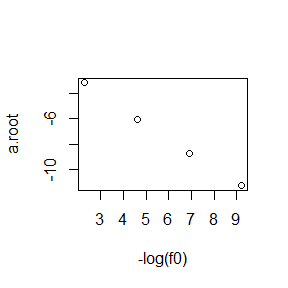

```r
plot(-log(f0),a.root)
```

# Question 2

Exercise 9.4

# Answer

### 下面的函数用来计算拉普拉斯分布的密度

```r
f<-function(x){
  1/2*exp(-abs(x))
}
```

### 使用正态建议分布生成拉普拉斯分布样本

```r
mh<-function(sd){
m<-10000
x<-numeric(m)

x[1]<-rnorm(1)
k<-0
u<-runif(m)

for(i in 2:m){
  xt<-x[i-1]
  y<-rnorm(1,mean=xt,sd=sd)
  num<-f(y)*dnorm(xt,mean=y,sd=sd)
  den<-f(xt)*dnorm(y,mean=xt,sd=sd)
  if(u[i]<=num/den){
    x[i]<-y
  }
  else{
    x[i]<-xt
    k<-k+1    #被拒绝的y的个数
  }
}

out<-list(rate=1-k/m,chain=x)
return(out)
}
```

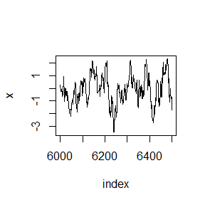

```r
set.seed(2)
mh1<-mh(0.5)
mh2<-mh(1)
mh3<-mh(2)

x1<-mh1$chain
x2<-mh2$chain
x3<-mh3$chain

index<-6000:6500

y1<-x1[index]
y2<-x2[index]
y3<-x3[index]

plot(index,y1,type="l",ylab="x")
```

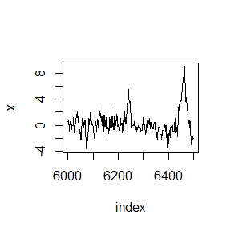

```r
plot(index,y2,type="l",ylab="x")
```

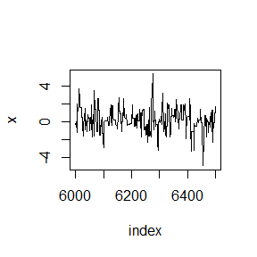

```r
plot(index,y3,type="l",ylab="x")
```

```r
c(mh1$rate,mh2$rate,mh3$rate)
```

```
## [1] 0.8217 0.6946 0.5340
```

从结果可以看出，方差越小，链条的接受率越大

# Question 3

习题9.7

# Answer

### 生成样本

```r
#initialize constants and parameters
N <- 5000                #链条长度
burn <- 1000             #链条要去掉前1000个数
X <- matrix(0, N, 2)     #链条（二维变量）

rho <- 0.9 #相关系数
mu1 <- 0
mu2 <- 0
sigma1 <- 1
sigma2 <- 1
s1 <- sqrt(1-rho^2)*sigma1
s2 <- sqrt(1-rho^2)*sigma2

#生成链条
set.seed(3)
X[1, ] <- c(mu1, mu2) #初始化
for (i in 2:N) {
x2 <- X[i-1, 2]
m1 <- mu1 + rho * (x2 - mu2) * sigma1/sigma2
X[i, 1] <- rnorm(1, m1, s1)
x1 <- X[i, 1]
m2 <- mu2 + rho * (x1 - mu1) * sigma2/sigma1
X[i, 2] <- rnorm(1, m2, s2)
}

b <- burn + 1
x <- X[b:N, ]
cor(x)
```

```
##          [,1]     [,2]
## [1,] 1.000000 0.899046
## [2,] 0.899046 1.000000
```

### 绘制生成样本的图形

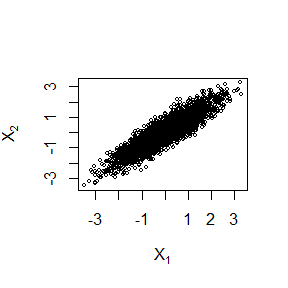

```r
plot(x, main="", cex=.5, xlab=bquote(X[1]),
ylab=bquote(X[2]), ylim=range(x[,2]))
```

### 做回归分析

```r
x_data.frame<-data.frame(x1=x[,1],x2=x[,2])
model<-lm(x2~x1,data=x_data.frame)
summary(model)
```

```
##
## Call:
## lm(formula = x2 ~ x1, data = x_data.frame)
##
## Residuals:
##      Min       1Q   Median       3Q      Max
## -1.57177 -0.28998 -0.00101  0.29684  1.70173
##
## Coefficients:
##              Estimate Std. Error t value Pr(>|t|)
## (Intercept) -0.007056   0.006889  -1.024    0.306
## x1           0.902345   0.006950 129.830   <2e-16 ***
## ---
## Signif. codes:  0 '***' 0.001 '**' 0.01 '*' 0.05 '.' 0.1 ' ' 1
##
## Residual standard error: 0.4355 on 3998 degrees of freedom
## Multiple R-squared:  0.8083, Adjusted R-squared:  0.8082
## F-statistic: 1.686e+04 on 1 and 3998 DF,  p-value: < 2.2e-16
```

即线性回归模型拟合结果为$X2=-0.007056+0.902345X1$

### 残差检验

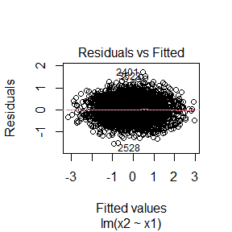

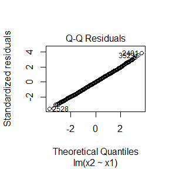

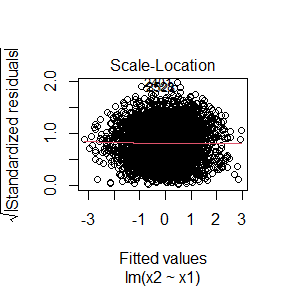

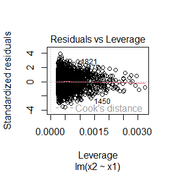

```r
plot(model)
```

# Question4

习题9.10

### 计算诊断统计量的函数

```r
Gelman.Rubin <- function(psi) {
# psi[i,j] is the statistic psi(X[i,1:j])
# for chain in i-th row of X
psi <- as.matrix(psi)
n <- ncol(psi)
k <- nrow(psi)
psi.means <- rowMeans(psi) #row means
B <- n * var(psi.means) #between variance est.
psi.w <- apply(psi, 1, "var") #within variances
W <- mean(psi.w) #within est.
v.hat <- W*(n-1)/n + (B/n) #upper variance est.
r.hat <- v.hat / W #G-R statistic
return(r.hat)
}
```

### 将M-H样本生成器写成函数

```r
f <- function(x, sigma) {
if (any(x < 0)) return (0)
stopifnot(sigma > 0)
return((x / sigma^2) * exp(-x^2 / (2*sigma^2)))
}

chisq.chain<-function(sigma,m){ #sigma=4,m=10000
xt <- x[i-1]
y <- rchisq(1, df = xt)

x <- numeric(m)
x[1] <- rchisq(1, df=1)
k <- 0
u <- runif(m)
for (i in 2:m) {
xt <- x[i-1]
y <- rchisq(1, df = xt)
num <- f(y, sigma) * dchisq(xt, df = y)
den <- f(xt, sigma) * dchisq(y, df = xt)
if (u[i] <= num/den) x[i] <- y else {
x[i] <- xt
k <- k+1 #y is rejected
}
}

return(x)
}
```

### 模拟4条链

```r
sigma <- 1 #parameter of proposal distribution
k <- 4 #number of chains to generate
n <- 15000 #length of chains
b <- 1000 #burn-in length

#generate the chains
set.seed(6)
X <- matrix(0, nrow=k, ncol=n)
for (i in 1:k)
X[i, ] <- chisq.chain(sigma, n)

#compute diagnostic statistics
psi <- t(apply(X, 1, cumsum))
for (i in 1:nrow(psi))
psi[i,] <- psi[i,] / (1:ncol(psi))
print(Gelman.Rubin(psi))
```

```
## [1] 1.117781
```

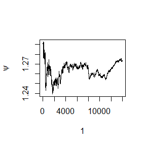

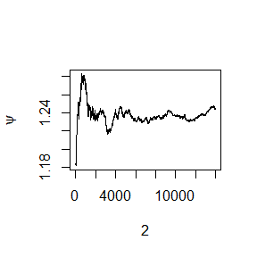

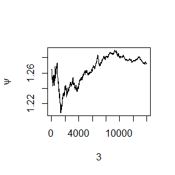

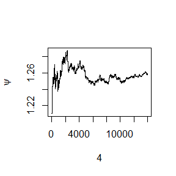

```r
#plot psi for the four chains
for (i in 1:k)
plot(psi[i, (b+1):n], type="l",
xlab=i, ylab=bquote(psi))
```

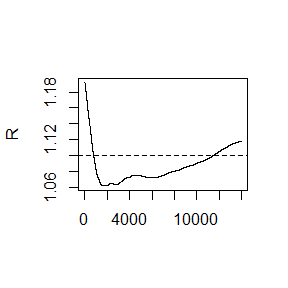

```r
par(mfrow=c(1,1)) #restore default

#plot the sequence of R-hat statistics
rhat <- rep(0, n)
for (j in (b+1):n)
rhat[j] <- Gelman.Rubin(psi[,1:j])
plot(rhat[(b+1):n], type="l", xlab="", ylab="R")
abline(h=1.1, lty=2)
```

# HW8 2023-11-13

# Question 1

求区间删失数据的MLE，证明EM算法收敛于MLE且有线性速度

# Answer

## 第1问

## 第2问

```r
f<-function(x){
  u<-c(11,8,27,13,16,0,23,10,24,2)
  v<-u+1

  sum((v*exp(-v*x)-u*exp(-u*x))/(exp(-u*x)-exp(-v*x)))
}
```

### 求lambda的极大似然估计

```r
uniroot(f,interval = c(0.01,1),tol=10^-5)
```

```
## $root
## [1] 0.07197378
##
## $f.root
## [1] -0.000550488
##
## $iter
## [1] 9
##
## $init.it
## [1] NA
##
## $estim.prec
## [1] 5e-06
```

即lambda的极大似然估计为0.07197

### 用EM算法估计lambda

```r
est<-10^-5                      #误差
n<-10
lambda0<-lambda1<-0.5
temp<-0
iter<-0                         #计数器

while(abs(temp-lambda1)>est){
  lambda1<-n/(n/lambda0-f(lambda0))
  temp<-lambda0
  lambda0<-lambda1
  iter<-iter+1
}

lambda0
```

```
## [1] 0.0719735
```

```r
iter
```

```
## [1] 3
```

即EM算法对lambda的估计值为0.07197,可以看到该值与MLE十分接近

# Question 2

习题11.8

# Answer

```r
solve.game <- function(A) {
#solve the two player zero-sum game by simplex method
#optimize for player 1, then player 2
#maximize v subject to ...
#let x strategies 1:m, and put v as extra variable
#A1, the <= constraints
#
min.A <- min(A)
A <- A - min.A #so that v >= 0
max.A <- max(A)
A <- A / max(A)
m <- nrow(A)
n <- ncol(A)
it <- n^3
a <- c(rep(0, m), 1) #objective function
A1 <- -cbind(t(A), rep(-1, n)) #constraints <=
b1 <- rep(0, n)
A3 <- t(as.matrix(c(rep(1, m), 0))) #constraints sum(x)=1
b3 <- 1
sx <- simplex(a=a, A1=A1, b1=b1, A3=A3, b3=b3,
maxi=TRUE, n.iter=it)
#the ’solution’ is [x1,x2,...,xm | value of game]
#
#minimize v subject to ...
#let y strategies 1:n, with v as extra variable
a <- c(rep(0, n), 1) #objective function
A1 <- cbind(A, rep(-1, m)) #constraints <=
b1 <- rep(0, m)
A3 <- t(as.matrix(c(rep(1, n), 0))) #constraints sum(y)=1
b3 <- 1
sy <- simplex(a=a, A1=A1, b1=b1, A3=A3, b3=b3,
maxi=FALSE, n.iter=it)
soln <- list("A" = A * max.A + min.A,
"x" = sx$soln[1:m],
"y" = sy$soln[1:n],
"v" = sx$soln[m+1] * max.A + min.A)
soln
}
```

```r
#enter the payoff matrix
A <- matrix(c( 0,-2,-2,3,0,0,4,0,0,
2,0,0,0,-3,-3,4,0,0,
2,0,0,3,0,0,0,-4,-4,
-3,0,-3,0,4,0,0,5,0,
0,3,0,-4,0,-4,0,5,0,
0,3,0,0,4,0,-5,0,-5,
-4,-4,0,0,0,5,0,0,6,
0,0,4,-5,-5,0,0,0,6,
0,0,4,0,0,5,-6,-6,0), 9, 9)
library(boot) #needed for simplex function
B <- A+2
s <- solve.game(B)
```

```r
round(cbind(s$x, s$y), 7)
```

```
##         [,1]      [,2]
## x1 0.0000000 0.0000000
## x2 0.0000000 0.0000000
## x3 0.4098361 0.4098361
## x4 0.0000000 0.0000000
## x5 0.3278689 0.3278689
## x6 0.0000000 0.0000000
## x7 0.2622951 0.2622951
## x8 0.0000000 0.0000000
## x9 0.0000000 0.0000000
```

即博弈B的解与博弈A相同，是原来博弈A的端点

# HW9 2023-11-20

# Question 1

2.1.3.4. Why do you need to use unlist() to convert a list to an atomic vector? Why doesn’t as.vector() work?

# Answer

R中的vector分为两类，atomic和list，二者的区别在于,前者元素类型必须相同，后者可以不同。前者的代表是向量和矩阵，后者的代表是list和数据框。

由于它们都是vector,所以用is.vector检验无法区分向量和列表。当然，也无法用as.vector将列表转换成向量。所以将list转化成atomic vector需要借助unlist。

# Question 2

2.3.1.1. What does dim() return when applied to a vector?

# Answer

```r
x<-c(1,2,3)
y<-matrix(c(1,2,3,4),nrow=2)
dim(x)
```

[output not shown]

```r
dim(y)
```

```
## [1] 2 2
```

dim函数只适用于矩阵和数据框，对于其他类型的变量，比如向量或者列表，dim函数将返回NULL

# Question 3

2.3.1.2. If is.matrix(x) is TRUE, what will is.array(x) return?

# Answer

```r
x<-matrix(c(1,2,3,4),nrow=2)
is.matrix(x)
```

```
## [1] TRUE
```

```r
is.array(x)
```

```
## [1] TRUE
```

is.array(x)会返回TRUE

# Question 4

2.4.5.2. What does as.matrix() do when applied to a data frame with columns of different types?

# Answer

```r
x<-data.frame(1:4,letters[1:4])
x<-as.matrix(x)
x
```

```
##      X1.4 letters.1.4.
## [1,] "1"  "a"
## [2,] "2"  "b"
## [3,] "3"  "c"
## [4,] "4"  "d"
```

```r
typeof(x)
```

```
## [1] "character"
```

```r
is.data.frame(x)
```

```
## [1] FALSE
```

```r
is.matrix(x)
```

```
## [1] TRUE
```

as.matrix将list转化为matrix,并且当其中的元素类型不同时,所有元素将被强制转化为最灵活的类型

# Question 5

2.4.5.3. Can you have a data frame with 0 rows? What about 0 columns?

# Answer

数据框可以有0行，当数据框的每一列都是长度为0的向量时，数据框的行数为0

```r
test=data.frame(col1=character(0),col2=numeric(0),col3=logical(0))
str(test)
```

```
## 'data.frame':    0 obs. of  3 variables:
##  $ col1: chr
##  $ col2: num
##  $ col3: logi
```

```r
test
```

```
## [1] col1 col2 col3
## <0 rows> (or 0-length row.names)
```

数据框的列数不能为0，否则数据框中没有向量

# Question 6

The function below scales a vector so it falls in the range [0, 1]. How would you apply it to every column of a data frame? How would you apply it to every numeric column in a data frame?

```r
scale01 <- function(x) {
rng <- range(x, na.rm = TRUE)  #获取一个长为2的向量，储存x的最小值和最大值
(x - rng[1]) / (rng[2] - rng[1])  #将x的每个元素映射到[0,1]上
}
```

# Answer

```r
data<-data.frame(1:5,c(F,F,F,T,T),2:6)  #构造一个数据框
```

```r
#将scale01运用到数据框每一列
lapply(data,scale01)
```

```
## $X1.5
## [1] 0.00 0.25 0.50 0.75 1.00
##
## $c.F..F..F..T..T.
## [1] 0 0 0 1 1
##
## $X2.6
## [1] 0.00 0.25 0.50 0.75 1.00
```

```r
#将scale01运用到数据框每一numeric列
lapply(data[lapply(data,is.numeric)==T],scale01)
```

```
## $X1.5
## [1] 0.00 0.25 0.50 0.75 1.00
##
## $X2.6
## [1] 0.00 0.25 0.50 0.75 1.00
```

# Question 7

1. Use vapply() to:
1. Compute the standard deviation of every column in a numeric data frame.
2. Compute the standard deviation of every numeric column in a mixed data frame. (Hint: you’ll need to use vapply() twice.)

# Answer

```r
#数据框全是numeric型元素
data1<-data.frame(1:5,2:6)  #构造一个纯数值数据框
vapply(data1,sd,numeric(1))
```

```
##     X1.5     X2.6
## 1.581139 1.581139
```

```r
#数据框是混合型元素
data2<-data.frame(1:5,letters[1:5],2:6)  #构造一个混合型数据框
vapply(data2[vapply(data,is.numeric,logical(1))==T],sd,numeric(1))
```

```
##     X1.5     X2.6
## 1.581139 1.581139
```

# Question 8

Consider Exercise 9.8 (pages 278, Statistical Computing with R). (Hint: Refer to the first example of Case studies section) • Write an R function. • Write an Rcpp function. • Compare the computation time of the two functions with the function “microbenchmark”.

# Answer

### R代码

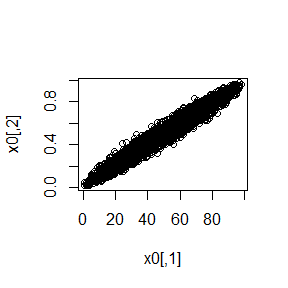

```r
N <- 5000 #length of chain
burn <- 1000 #burn-in length
X <- matrix(0, N, 2) #the chain, a bivariate sample
a<-2
b<-2
n<-100
x<-1     #x的初始值
y<-0.5   #y的初始值

###### 生成链 #####
set.seed(1)
X[1, ] <- c(x, y) #初始化
for (i in 2:N) {
y <- X[i-1, 2]
X[i, 1] <- rbinom(1,n,y)
x <- X[i, 1]
X[i, 2] <- rbeta(1,x+a,n-x+b)
}

d <- burn + 1
x0 <- X[d:N, ]

plot(x0)
```

### Rcpp代码

```r
library(Rcpp)

sourceCpp(code='
#include <Rcpp.h>
#include <iostream>
#include <ctime>
#include <random>
using namespace Rcpp;

//[[Rcpp::export]]
long cls_random::randomBinomial(long N,double probability){
    long rnd = 0;
    for (long i=0;i<N;i++){
        double pV = (double)rand()/(double)RAND_MAX;
        if (pV<probability){
            rnd++;
        }
    }
  return rnd;
}

double cls_random::randomBeta(double alpha,double beta){
    double u, v;
    double x, y;
    do
    {
        u=cls_random::randomUniform();
        v=cls_random::randomUniform();
        x=pow(u,1/alpha);
        y=pow(v,1/beta);
    } while (x+y>1);
    return x/(x+y);
}

  NumericVector iters(int a,int b,int n,int x,int y){
    int N=5000;
    int X[N][2];
    int x1;
    int y1;

    X[0][0]=x;
    X[0][1]=y;

    for(int i=1;i<N;i++) {
    y1=X[i-1][1];
    X[i][0]=cls_random::randomBinomial(n,y);
    x1=X[i][0];
    X[i][1]=cls_random::randomBeta(x+a,n-x+b);
    }

    return X;
  }
')

X<-iters(2,2,100,1,0.5)
x0 <- X[1001:10000, ]
plot(x0)
```

[output not shown]